# Project: Predicting Boston Housing Prices

*"Let me tell you a good story..." - Pei Sim*

#### Intoduction

- Dataset & BackStory
- Data Exploration
  - Basic Statistics
  - Visualization: Histogram
- Split Data into Train and Validation sets

#### Developing Models

- Baseline Model
- Implementing Linear Regression from Scratch
  - Machine Learning Abstractions
  - Visualization: Line Fitting
  - Linear Regression as Python Class - Abstraction in Software Engineering
  - Make Your Own Prediction
- Decision Tree Regressor

#### Analyzing Performances

- Defining a Performance Metric - R2
- Comparing Accuracies of Different Models
- Learning Curves and Complexity Curves
- Bias-Variance Tradeoffs
- Parameter Optimization - Grid Search
  - Improved accuracy!

#### Real world Relevance/Applicability

- Sensitivity

## Introduction

### Background Story

Suppose you suddenly find yourself in financial hardship and you are desperately trying to sell your property. You know that if you did that through a third party (aka real estate agency), you would need to share a proportion of the profit from the sale with them.

Further suppose it's now 1978 and that you live in the suburbs of Boston and you have access to the following [info about housing prices in your area](https://archive.ics.uci.edu/ml/datasets/Housing).

With your knowledge in machine learning, you can **predict the price at which you can sell your house such that the profit is maximized**.

```python
# Import libraries necessary for this project
import numpy as np
import pandas as pd
import matplotlib.pyplot as plt
import visuals as vs # Supplementary code
from sklearn.cross_validation import ShuffleSplit

# Pretty display for notebooks
%matplotlib inline

# ignore some warnings
import warnings
warnings.filterwarnings('ignore')
```

### Data Exploration

For the purposes of this project, the following preprocessing steps have been made to the dataset:

- 16 data points have an `'MDEV'` value of 50.0. These data points likely contain **missing or censored values** and have been removed.
- 1 data point has an `'RM'` value of 8.78. This data point can be considered an **outlier** and has been removed.
- The features `'RM'`, `'LSTAT'`, `'PTRATIO'`, and `'MDEV'` are essential. The remaining **non-relevant features** have been excluded. (I will revisit this in the future)
- The feature `'MDEV'` has been **multiplicatively scaled** to account for 35 years of market inflation.

```python
data = pd.read_csv('housing.csv')
data.head()
```

|  | RM | LSTAT | PTRATIO | MDEV |
| --- | --- | --- | --- | --- |
| 0 | 6.575 | 4.98 | 15.3 | 504000.0 |
| 1 | 6.421 | 9.14 | 17.8 | 453600.0 |
| 2 | 7.185 | 4.03 | 17.8 | 728700.0 |
| 3 | 6.998 | 2.94 | 18.7 | 701400.0 |
| 4 | 7.147 | 5.33 | 18.7 | 760200.0 |

**Explanation**

The following are the factors that are usually considered when a person is looking to purchase a house:

1. RM: average number of rooms per dwelling
2. LSTAT: % lower status of the population
3. PTRATIO: pupil-teacher ratio by town
4. MEDV: Median value of owner-occupied homes in $1000's (MEDV is the value of the property)

```python
prices = data['MDEV'].values
features = data.drop('MDEV', axis = 1)
```

In the two line of code above, I'm splitting the data into

1. `prices`: the price of the properties
2. `features`: the features of the properties (the number of rooms etc)

### Statistics

```python
number_of_properties = data.shape[0]
minimum_price = np.min(prices)
maximum_price = np.max(prices)
mean_price = np.mean(prices)
median_price = np.median(prices)
std_price = np.std(prices)


print "Statistics for {n} Boston properties:\n".format(n=number_of_properties)
print "Minimum price: ${:,.2f}".format(minimum_price)
print "Maximum price: ${:,.2f}".format(maximum_price)
print "Mean price: ${:,.2f}".format(mean_price)
print "Median price ${:,.2f}".format(median_price)
print "Standard deviation of prices: ${:,.2f}".format(std_price)
```

```
Statistics for 489 Boston properties:

Minimum price: $105,000.00
Maximum price: $1,024,800.00
Mean price: $454,342.94
Median price $438,900.00
Standard deviation of prices: $165,171.13
```

### Visualization

**Prices of the properties:** As we can see below, there are just below 150 houses valued at $450,000.

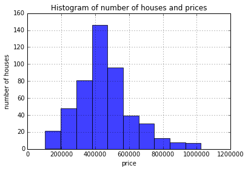

```python
plt.hist(prices, alpha=0.75)
plt.grid(True)
plt.xlabel('price')
plt.ylabel('number of houses')
plt.title('Histogram of number of houses and prices')
```

**Number of Rooms of the properties:** As we can see blow, most properties in the suburbs of Boston have 6 rooms.

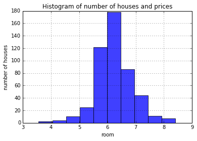

```python
plt.hist(features['RM'], alpha=0.75)
plt.grid(True)
plt.xlabel('room')
plt.ylabel('number of houses')
plt.title('Histogram of number of houses and prices')
```

**Aside: What a Histogram is**  
Histograms are used to display the distributions of quantitative variables. Bar charts display one quantity per category. They are often used to display the distributions of categorical variables.

### Split Data Into Train and Validation Sets

Here, we are taking the Boston housing dataset and splitting it intor training and validation sets. Data is also shuffled into random order to remove any bias that may be inherent in the data.

Astute readers may be wondering: what is the benefit to splitting a dataset into some ratio of training and testing subsets for a learning algorithm?

The short answers to the question above are as follow:

1. Without splitting there is no way to test the effectiveness of our model, unless we have additional data.
2. We want our model to generalize, as in, predicting the price of a house it hasn't seen before (in our dataset) as accurately as possible. If we don't have a way to test our model, our model might be overfitting the data in our training set, hence, it might end up predicting the price of a new house very inaccurately.

The code below splits the 80% of the original data into the training set and 20% into the validation set.

```python
from sklearn.cross_validation import train_test_split
X_train, X_test, y_train, y_test = train_test_split(features, prices, test_size=0.2, random_state=10)
```

## Developing Models

### Baseline model

A **naive model** would be to predict the price of any house to be the **average** (mean, in statistics speak) price in the area **regardless of the features of the house**. This is obviously not a good model as it gives the same value to a house with 5 rooms and a house with 1 room.

However, it gives us a baseline to evaluate other models against. If the models we come up with perform worse than this naive model, then, we know that there must be some bug in our implementation!

```python
class NaiveModel:

    def fit(self, X_train, y_train):
        self.pred = np.mean(y_train)
        return self

    def predict(self, X):
        preds = np.array([self.pred for _ in range(X.shape[0])])
        return preds
```

### Implementation: Linear Regression

It is often helpful to solve a simpler problem. In our case of predicting housing prices based on property features, we can **look at just the number of rooms and ignore all the other features**.

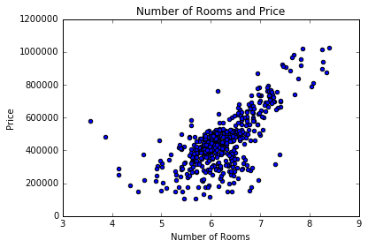

```python
rooms = data['RM'].values
rooms = np.reshape(rooms, (len(rooms), 1))
plt.scatter(rooms, prices)
plt.title('Number of Rooms and Price')
plt.xlabel('Number of Rooms')
plt.ylabel('Price')
```

The plot above simply tells us that **the greater the number of rooms in a property, the higher the price of the property is**.

Make sense, right?

#### Machine Learning Abstraction

To perform linear regression (aka fitting curve to data points), we need to define the following:

1. Hypothesis This is our function that takes in the number of rooms (feature) and outputs the prediction for the price of the property:

   $$h_\theta(x) = \Theta_0 + \Theta_1*x_1 $$
2. Cost Function We need a way to evaluate the performance of our algorithm. For linear regression, we can use something called the **mean squared error loss**. Essentially, we compute squared of the error the algorithm makes.

   In our dataset, error is defined as the difference between the **actual housing price** and the **predicted housing price**:

   $$error = prediction - actual$$

   $$error = h_\theta(x) - y$$
3. Optimization function If you will, the machine learning is basically to learn the Theta, aka the model. To do that, we can use **gradient descent**. The update rule is the following:

   $$\Theta = \Theta - \alpha \frac{1}{m} \Sigma_{i = 1}^{m} (h_\theta(x^{(i)})-y^{(i)})x^{(i)}$$

where $\alpha$ is called learning rate, also known as the step size. It should be chosen empirically because the best choice depends upon the input problem.

If the **learning rate is too small**, it will take a long time for the algorithm to converge.

If the **learning rate is too big**, it might take a long time to converge as well, but for a different reason: it jumps right over the region with zero risk and oscillates back and forth for a long time.

Now, we are ready to translate the above to code!

```python
def predict(X, Theta):
    return X.dot(Theta)

def cost(X, Y, Theta):
    return np.sum((predict(X, Theta) - Y)**2)/(2*len(X))

def descend(X, Y, Theta, alpha):
    return Theta - alpha*(np.mean(predict(X, Y, Theta) - Y)**2)/len(X)
```

#### Linear Regression as Python Class

To make the code cleaner, we can also implement the machine learning algorithm in a Python Class, thus abstracting certain things from the user, which is a common software engineering practice.

```python
class LinearRegressionGD(object):

    def __init__(self, alpha=0.002, num_iter=50):
        self.alpha = alpha
        self.num_iter = 50
        self.costs = []

    def fit(self, X, y):
        self.model = np.zeros(1 + X.shape[1])

        for i in range(self.num_iter):
            prediction = self.predict(X)
            errors = y - prediction
            self.model[1:] += self.alpha * X.T.dot(errors)
            self.model[0] += self.alpha * np.sum(errors)
            cost = np.sum(np.power(errors, 2))/len(X)
            self.costs.append(cost)

        return self.costs

    def predict(self, X):
        return np.dot(X, self.model[1:]) + self.model[0]
```

#### Training

Now, we can train our model.

We also rescale our data.

```python
from sklearn.preprocessing import StandardScaler
sc_x = StandardScaler()
sc_y = StandardScaler()
X_std = sc_x.fit_transform(rooms)
y_std = sc_y.fit_transform(prices)
lr = LinearRegressionGD()
costs = lr.fit(X_std, y_std)
```

#### Visualization

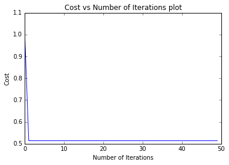

```python
plt.title('Cost vs Number of Iterations plot')
plt.xlabel('Number of Iterations')
plt.ylabel('Cost')
plt.plot(costs)
```

Explanation: As we can see, our cost converges pretty quickly. Hence our algorithm does not have any bug!

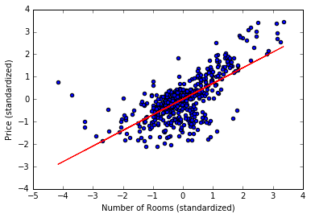

```python
plt.scatter(X_std, y_std, c='blue')
plt.plot(X_std, lr.predict(X_std), color='red')
plt.xlabel("Number of Rooms (standardized)")
plt.ylabel("Price (standardized)")
```

#### Make Your Own Prediction

Continuing our story, let's suppose that now you have a property with 5 rooms, our model can now inform you **the price at which you should be selling your property**!

```python
num_rooms = 5
num_rooms_std = sc_x.transform([num_rooms])
price_std = lr.predict(num_rooms_std)
print("For a house with " + str(num_rooms) + " rooms:")
print("Linear Regression Model For Sale Price is ${:,}".format(int(sc_y.inverse_transform(price_std))))
```

```
For a house with 5 rooms:
Linear Regression Model For Sale Price is $232,209
```

### Decision Tree Regressor

Above we have seen the implementation of a naive model—which always predicts the average price in the area regardless of the features of the house, as well as **linear regression**, measuring the "goodness of fit" using **mean squared error**.

Now, we are going to explore a different model called Decision Tree Regressor.

Decision Trees are usually used when we care about the interpretability of our model. For instance, in the example below, decision trees learn from data to approximate a sine curve with a set of if-then-else decision rules. The deeper the tree, the more complex the decision rules and the fitter the model.<sup>[1](http://scikit-learn.org/stable/auto_examples/tree/plot_tree_regression.html)</sup>

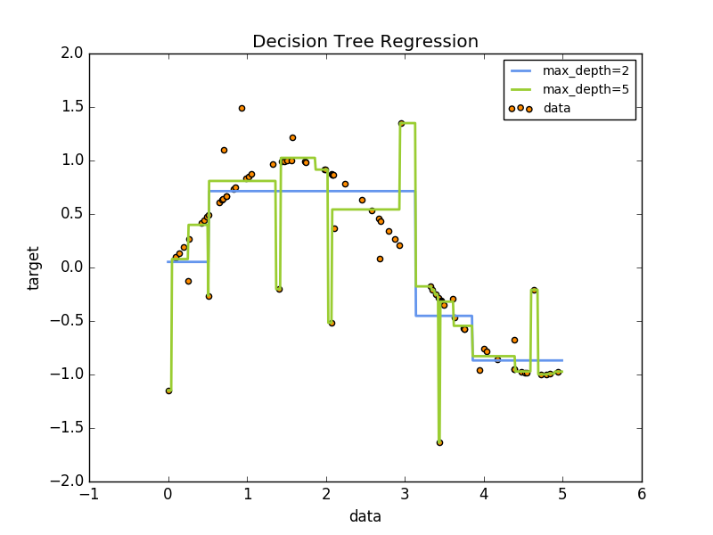

```python
from IPython.display import Image
Image(filename='sphx_glr_plot_tree_regression_001.png')
```

In this notebook, I'm not implementing a Decision Tree from scratch.

However, if you're interested, I have built [a spam classifer](http://www.pysim.me/projects/spam.html) using my very own Random Forest (a collection of Decision Trees).

```python
from sklearn.tree import DecisionTreeRegressor
regressor = DecisionTreeRegressor(max_depth=3)
```

```python
regressor.fit(X_std, y_std)
price_std = regressor.predict(num_rooms_std)
print("For a house with " + str(num_rooms) + " rooms:")
print("Decision Tree Model For Sale Price is ${:,}".format(int(sc_y.inverse_transform(price_std))))
```

```
For a house with 5 rooms:
Decision Tree Model For Sale Price is $300,037
```

**Explanation**: So, as we can see, the predictions made by our linear regression model and Sklearn's built-in decision tree regressor are different. Thus, it makes sense to analyze the performances in more detail.

## Analyzing Performances

### Coefficient of Determination, R^2

We are now going to train our 3 models (naive, linear regression, decision tree) on the training set with all housing features and then compute the $R^2$ score for each of them.

$R^2$ is known as the coefficient of determination. It is a useful statistic in describing how good a model is at making predictions.

The values for $R^2$ range from 0 to 1, which captures the percentage of squared correlation between the predicted and actual values of the target variable. A model with an $R^2$ of 0 always fails to predict the target variable, whereas a model with an $R^2$ of 1 perfectly predicts the target variable. Any value between 0 and 1 indicates what percentage of the target variable, using this model, can be explained by the features.

```python
from sklearn.metrics import r2_score

def eval_model(model):
    """ Calculates and returns the performance score between
    true and predicted values based on the metric chosen. """
    model.fit(X_train, y_train)
    train_preds = model.predict(X_train)
    print("Train accuracy: " + str(r2_score(y_train, train_preds)))
    test_preds = model.predict(X_test)
    print("Test accuracy: " + str(r2_score(y_test, test_preds)) + '\n')
```

### Accuracies Between Different Models

```python
# naive
print("Naive model: ")
naive = NaiveModel()
eval_model(naive)

# Sklearn Linear Regression
from sklearn.linear_model import LinearRegression
print("Sklearn's Linear Regression: ")
linReg = LinearRegression()
eval_model(linReg)

# Decision Tree
from sklearn.tree import DecisionTreeRegressor
print("Sklearn's Decision Tree Regressor: ")
tree = DecisionTreeRegressor(max_depth=3)
eval_model(tree)
```

```
Naive model:
Train accuracy: 0.0
Test accuracy: -0.000194537494617

Sklearn's Linear Regression:
Train accuracy: 0.714917158472
Test accuracy: 0.724353104621

Sklearn's Decision Tree Regressor:
Train accuracy: 0.83248729586
Test accuracy: 0.665044566531
```

### Learning Curves and Complexity Curves

In Data Science, visualizations are often used in helping us make decisions.

Below, we are plotting the learning and complexity curves.

They help us get an idea of how well the model can generalize to new data. In the plots below, both learning curves converges to 0.78 when `max_depth = 3`. When `max_depth = 10`, our Decision Tree is **overfitting**, thus, it performs well on the training set and relatively poorly on unseen data (test set).

The only difference between the two is that learning curves measure a model's performance on **experience** (if you have a higher number of training points, you have more experience) while complexity curves measure a model's performance based on the complexity of the model (in decision trees, models become more complex as depth increases).

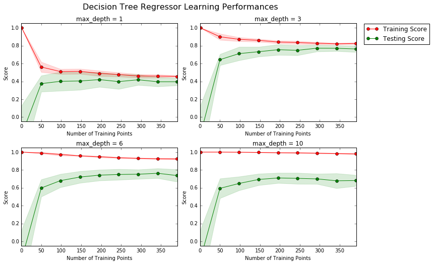

```python
# Produce learning curves for varying training set sizes and maximum depths
vs.ModelLearning(features, prices)
```

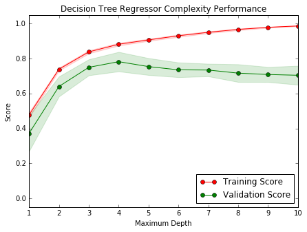

```python
vs.ModelComplexity(X_train, y_train)
```

### Bias-Variance Tradeoffs

max_depth = 1: high bias, because both the training and test scores are low, hence, model is underfitting.

max_depth = 10: high variance, because the training score is much higher than the test score, hence, model is overfitting.

### Grid Search

Grid search is a way of performing hyperparameter optimization by exhaustively searching through a manually specified subset of the hyperparameter space. Its performance is measured on the cross-validation set. The technique chooses the value of the hyperparameter that performs best on the cross-validation set.

Here, we are going to use grid search to optimize the `'max_depth'` parameter for our decision tree model.

```python
from sklearn.tree import DecisionTreeRegressor
from sklearn.grid_search import GridSearchCV
from sklearn.metrics import make_scorer

def fit_model(X, y):
    cv_sets = ShuffleSplit(X.shape[0], n_iter = 10, test_size = 0.20, random_state = 0)
    regressor = DecisionTreeRegressor()
    params = {'max_depth': [i for i in range(1, 11)]}
    scoring_fnc = make_scorer(performance_metric)
    grid = GridSearchCV(regressor, params, cv=cv_sets, scoring=scoring_fnc)
    grid = grid.fit(X, y)
    return grid.best_estimator_
```

```python
# Fit the training data to the model using grid search
reg = fit_model(X_train, y_train)

# Produce the value for 'max_depth'
print "Parameter 'max_depth' is {} for the optimal model.".format(reg.get_params()['max_depth'])
```

```
Parameter 'max_depth' is 4 for the optimal model.
```

**We should now see an increase in the accuracy of our predictions**

```python
# Decision Tree
from sklearn.tree import DecisionTreeRegressor
print("Sklearn's Decision Tree Regressor: ")
tree = DecisionTreeRegressor(max_depth=4)
eval_model(tree)
```

```
Sklearn's Decision Tree Regressor:
Train accuracy: 0.877439483671
Test accuracy: 0.75435934469
```

And, it did not disappoint!

## Applicability

#### Sensitivity

An optimal model is not necessarily a robust model. Sometimes, a model is either too complex or too simple to sufficiently generalize to new data. Sometimes, a model could use a learning algorithm that is not appropriate for the structure of the data given. Other times, the data itself could be too noisy or contain too few samples to allow a model to adequately capture the target variable — i.e., the model is underfitted. Run the code cell below to run the fit_model function ten times with different training and testing sets to see how the prediction for a specific client changes with the data it's trained on.

```python
def predictTrials(X, y, fitter, data):
    """ Performs trials of fitting and predicting data. """

    # Store the predicted prices
    prices = []

    for k in range(10):
        # Split the data
        X_train, X_test, y_train, y_test = train_test_split(X, y, \
            test_size = 0.2, random_state = k)

        # Fit the data
        reg = fitter(X_train, y_train)

        # Make a prediction
        pred = reg.predict([data[0]])[0]
        prices.append(pred)

        # Result
        print "Trial {}: ${:,.2f}".format(k+1, pred)

    # Display price range
    print "\nRange in prices: ${:,.2f}".format(max(prices) - min(prices))
```

```python
client_data = [[4, 55, 22]]
predictTrials(features, prices, fit_model, client_data)
```

```
Trial 1: $189,123.53
Trial 2: $287,100.00
Trial 3: $236,478.26
Trial 4: $235,122.22
Trial 5: $280,980.00
Trial 6: $235,620.00
Trial 7: $238,132.08
Trial 8: $229,200.00
Trial 9: $243,857.89
Trial 10: $228,385.71

Range in prices: $97,976.47
```

Though our model attains a 75% accuracy on unseen data, it has great variability (for the client above, the range of predictions is as high as 97,000).

Thus, it's not as robust as we'd hoped. A solution to this would be to construct a confidence interval to measure how confident we are with the estimation of the housing prices (statistic) against the true prices (parameter).